# Unit 12 - Instrumental Variables

Jim Flynn

November 2, 2026

## The Canonical IV setup

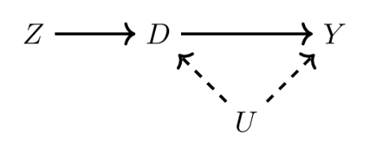

- D is the treatment we are interested in
- A good IV (Z) has two properties:
  - $cov(Z,D) \neq 0$ (first-stage)
  - $cov(Z,\epsilon) = 0$ (exclusion restriction)

## Why do we need an IV?

- Omitted Variable Bias (ability)
- Simultaneity (supply and demand)
- Measurement error
- General endogeneity

## A good IV should feel **weird**

- It should not immediately make sense when you describe it to someone
- Need to be able to defend the **exclusion restriction**
  - This means that it shouldn’t logically make sense that Z affects Y
  - If it does, it **must** be through an effect on X
- In metrics terms: **The IV is irrelevant to the outcome except for its effect on the endogenous variable**

## Examples of IVs

Regulating cold meds $\implies$ ??? $\implies$ Foster care

Child’s birthday $\implies$ ??? $\implies$ Odds of getting flu

Age of menarche $\implies$ ??? $\implies$ Education

Sex of 1st 2 kids $\implies$ ??? $\implies$ Mom’s labor supply

Election year $\implies$ ??? $\implies$ Crime

Marathons $\implies$ ??? $\implies$ Odds of surviving cardiac arrest (non-runners)

## What’s the point

- We want to know the effect of X on Y, but this is endogenous
- We need variation in X that is free of OVB and simultaneity
- IV that strongly affects X but does not affect Y gives us what we need
- This exogenous variation in X allows us to capture the effect of X on Y

## Let’s walk through an example

- You want to estimate:

$Y_i = \alpha + \beta X_i + \gamma U_i + \epsilon_i$

- But U is unobserved, so you run:

$Y_i = \alpha + \beta X_i + \eta_i$

- Where

$\eta_i = \gamma U_i + \epsilon_i$

- We have an OVB problem where:

$OVB = \gamma \frac{C(U,X)}{V(X)}$

## OVB gives us biased estimate

- We want to estimate $\beta$
- We clearly can’t do that in one step
- What if we could estimate something that we *know* includes $\beta$
  - Then, if we know the other piece, we could back into an estimate of $\beta$ by itself

## Some definitions will help us

- **Structural Equation** - this is the *true* equation that describes the world
  - May not be estimable
- **First stage** - equation that shows the effect of Z on X
- **Reduced Form** - This is where we will plug the first-stage into the structural equation

## In our setting

- Structural equation:

$Y_i = \alpha + \beta X_i + \gamma U_i + \epsilon_i$

- First stage:

$X_i = \delta_0 + \delta_1 Z_i + \rho_i$

- Reduced form:

$Y_i = \alpha + \beta (\delta_0 + \delta_1 Z_i + \rho_i) + \gamma U_i + \epsilon_i$

$Y_i = \alpha + \beta \delta_0 + \underbrace{\beta \delta_1}_{\text{Our focus}} Z_i + \beta\rho_i + \gamma U_i + \epsilon_i$

## What is the reduced form coefficient?

$\frac{Cov(Z,Y)}{Var(Z)} =\frac{Cov(Z, \underbrace{\alpha + \beta \delta_0}_{constants} + \beta \delta_1 Z_i + \underbrace{\beta\rho_i}_{constant} + \gamma U_i + \epsilon_i)}{Var(Z)}$

$\equiv \frac{Cov(Z, \beta \delta_1 Z_i + \underbrace{\gamma U_i + \epsilon_i}_{\text{0 by assumption}})}{Var(Z)}$

$\equiv \frac{Cov(Z, \beta \delta_1 Z_i)}{Var(Z)} = \beta \delta_1 \frac{Var(Z)}{Var(Z)} = \underbrace{\beta \delta_1}_{\text{This includes }\beta!}$

## We have $\beta$, what is $\delta_1$ again?

- $\delta_1$ is the coefficient on $Z$ from the first stage, so:

$$\frac{\frac{Cov(Z,Y)}{Var(Z)}}{\frac{Cov(Z,X)}{Var(Z)}}=
\frac{Cov(Z,Y)}{Cov(Z,X)}= \frac{\beta \delta_1}{\delta_1}=
\beta$$
This gives us an unbiased coefficient for $\beta$!

## OK we can find $\beta$, but how do we do this via regressions?

- There are multiple ways
- We will use a procedure called **two-stage least squares**
  - aka 2sls
- Uses OLS and has simple, intuitive design

## Let’s set this up

```r
Z <- rnorm(10000)
U <- rnorm(10000)
X <- rnorm(10000) + 1*Z + 2*U
Y <- rnorm(10000) + 3*X + 4*U
```

- Z is our instrument
- U is our omitted variable (ability)
- X is our variable of interest
- Y is our outcome

## Run the OVB version

```r
ovb <- lm(Y~X)
summary(ovb)$coefficients
```

```
##                Estimate Std. Error     t value  Pr(>|t|)
## (Intercept) -0.01267391 0.02518056  -0.5033213 0.6147495
## X            4.30832183 0.01029026 418.6794147 0.0000000
```

## We can fix this by controlling for U

```r
ctrl <- lm(Y~X+U)
summary(ctrl)$coefficients
```

```
##                 Estimate  Std. Error     t value  Pr(>|t|)
## (Intercept) -0.005599872 0.009985955  -0.5607748 0.5749636
## X            2.993624618 0.006993912 428.0329257 0.0000000
## U            3.998390510 0.017274381 231.4636093 0.0000000
```

## Now we will manually calculate the IV version

```r
first_stage <- lm(X~Z)
X_hat <- fitted.values(first_stage)

iv_manual <- lm(Y~X_hat)
summary(iv_manual)$coefficients
```

```
##                Estimate Std. Error    t value      Pr(>|t|)
## (Intercept) -0.02213971  0.1039155 -0.2130551  8.312884e-01
## X_hat        3.02264689  0.1017588 29.7040276 6.905390e-186
```

## We can also take the ratio of the covariances

```r
cov_zy <- cov(Z,Y)
cov_zx <- cov(Z,X)

beta_iv <- cov_zy/cov_zx
beta_iv
```

```
## [1] 3.022647
```

## Now we let R do this for us

```r
library('ivreg')
iv <- ivreg(Y~X|Z)
summary(iv)
```

```
##
## Call:
## ivreg(formula = Y ~ X | Z)
##
## Residuals:
##       Min        1Q    Median        3Q       Max
## -16.86318  -2.76122  -0.05379   2.69884  15.79064
##
## Coefficients:
##             Estimate Std. Error t value Pr(>|t|)
## (Intercept) -0.02214    0.04030  -0.549    0.583
## X            3.02265    0.03946  76.593   <2e-16 ***
##
## Diagnostic tests:
##                   df1  df2 statistic p-value
## Weak instruments    1 9998      2108  <2e-16 ***
## Wu-Hausman          1 9997      4907  <2e-16 ***
## Sargan              0   NA        NA      NA
## ---
## Signif. codes:  0 '***' 0.001 '**' 0.01 '*' 0.05 '.' 0.1 ' ' 1
##
## Residual standard error: 4.03 on 9998 degrees of freedom
## Multiple R-Squared: 0.8618,  Adjusted R-squared: 0.8618
## Wald test:  5866 on 1 and 9998 DF,  p-value: < 2.2e-16
```

## How does this typically look in papers

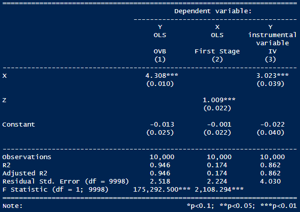

```r
library(stargazer)
stargazer(ovb,first_stage,iv, stars = TRUE, type="text",
          column.labels = c("OVB","First Stage", "IV"))
```

## Class exercise

- What happens if $Cov(Z,U)\neq0$
- What about if $Cov(Z,Y)\neq0$

## Solution 1

```r
Z <- rnorm(10000)
U <- rnorm(10000) + 3*Z
X <- rnorm(10000) + 1*Z + 2*U
Y <- rnorm(10000) + 3*X + 4*U

summary(ivreg(Y~X|Z))$coefficients[1:2,1:4]
```

```
##               Estimate  Std. Error     t value  Pr(>|t|)
## (Intercept) 0.02246663 0.020716491    1.084481 0.2781779
## X           4.70976970 0.002908806 1619.141808 0.0000000
```

## Solution 2

```r
Z <- rnorm(10000)
U <- rnorm(10000)
X <- rnorm(10000) + 1*Z + 2*U
Y <- rnorm(10000) + 3*X + 4*U + 3*Z

summary(ivreg(Y~X|Z))$coefficients[1:2,1:4]
```

```
##               Estimate Std. Error     t value Pr(>|t|)
## (Intercept) 0.01144851 0.03588218   0.3190582 0.749689
## X           5.93473181 0.03358785 176.6928241 0.000000
```

## Are there any drawbacks?

- Notice that we used only a subset of the variation in X
- Because of this, standard errors got bigger
  - We lose precision with IV
  - Power becomes very important
  - Especially power in the first stage

## Weak Instruments problem

- What happens if the relationship between the IV and X is not that strong?
  - We will obviously lose precision
  - Our estimate will also become **biased**

Let OLS bias be:

$Bias_{OLS} = E[\hat{\beta}_{OLS}-\beta] = \frac{Cov(\epsilon,X)}{Var(X)}$

## Bias returns to OLS bias as instrument gets weaker

$E[\hat{\beta}_{2SLS}-\beta] = (Bias_{OLS}) \frac{1}{F+1}$

Where F is the F-stat on Z from the first-stage regression

- As $F \to \infty$, $\hat{\beta}_{2SLS} \to \beta$
- As $F \to 0$, $\hat{\beta}_{2SLS} \to \beta_{OLS}$

## What is an F-stat again?

- F-stat of a single variable $Z$ in a regression is:

$$\frac{SSR_{old}-SSR_{new}}{n-k}$$

- Where
  - $SSR_{old}$ is the SSR **without** including $Z$
  - $SSR_{new}$ is the SSR including $Z$
  - $k$ is the total number of independent variables
- To get a large $F$, $Z$ needs to explain a lot of variation in X

## What’s the difference between T and F?

- When $k=1$, $T^2=F$
  - $T = \frac{\hat{\beta}}{SE_{\hat{\beta}}}$, $F = \frac{SSR_{old}-SSR_{new}}{n-k}$
- The difference is that F is more flexible
- Can test multiple variables/instruments
- T can only test one

## Class exercise

- Write a simulation with 1000 regressions
- X and Y uncorrelated
- Save T and F from each round
- Make a scatter plot of T and F
- This is how you save F

```r
library(car)
X <- rnorm(1000)
Y <- rnorm(1000)
lm1 <- lm(Y~X)
F <- linearHypothesis(lm1,"X=0")$F[2]
F
```

```
## [1] 0.4236014
```

## Solution

```r
df <- data.frame(matrix(ncol=2,nrow=1000))
colnames(df) <- c("T", "F")

for (i in 1:1000) {

X <- rnorm(1000)
Y <- rnorm(1000)

lm1 <- lm(Y~X)

T <- summary(lm1)$coefficients[2,3]
F <- linearHypothesis(lm1,"X=0")$F[2]

df[i,1] <- T
df[i,2] <- F
}
```

## Solution scatterplot

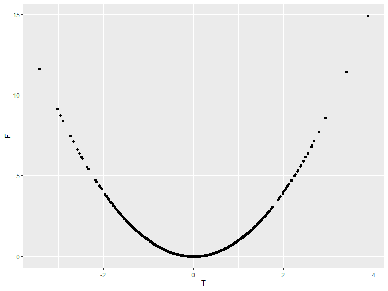

```r
library(ggplot2)
ggplot(df, aes(x=T,y=F)) +
  geom_point()
```

## Fortunately we can test for weak instruments

```r
Z <- rnorm(10000)
U <- rnorm(10000)
X <- rnorm(10000) + 1*Z + 2*U
Y <- rnorm(10000) + 3*X + 4*U

first_stage <- lm(X~Z)
F <- linearHypothesis(first_stage,"Z=0")$F[2]
F
```

```
## [1] 1864.421
```

- For a valid instrument, want an F-stat of **at least** 10
  - Roughly translates to $T>3.2$
- Really, we probably want bigger than this
- You will learn all about this in PS5

## Heterogeneous Treatment Effects

- So far, an unstated assumption has been that everyone has the same treatment effect:

$y_i^1-y_i^0 = \delta$ for all $i$

- Of course, this isn’t always true
- In fact, it’s almost never true
- This introduces a tradeoff between the **internal validity** of a study and the **external validity**
- Also changes our interpretation of the parameter
- It also means we need to make three additional assumptions

## Assumption 1 - SUTVA

- SUTVA - Stable Unit Treatment Value Assumption
  - Potential outcomes for each person are unrelated to treatment status of others
  - Spillovers are an example
- Example - looking at the effect of Walmart openings on employment
  - Can’t include neighboring towns because they are partially treated

## Assumption 2 - Independence

- States that assignment of the instrument must be ‘as good as random’
- Must be unrelated to potential outcomes or potential treatment
- If IV targets those who benefit most, we have a problem

## Assumption 3 - Monotonicity

- Sounds complicated but is actually straightforward
- Monotonicity says “the IV (weakly) operates in the same direction on all units”
- Some people can be unaffected
- Everyone who **is** affected must be pushed in the same direction.

## Explaining monotonicity

- Using PO notation once again
- Each unit starts by getting a value of $Z$ (0 or 1)
- Then, they get a value of $D$ (also 0 or 1)
- $D_1 = 0$ means they got a 1 for $Z$ but a 0 for $D$
- This is like someone having two girls but then deciding they are done This would not violate monotonicity

## Monotonicity cont’d

- Monotonicity essentially says “no defiers”

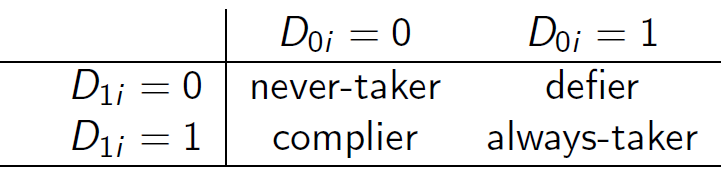

- A defier would stop having kids after 2 girls (or 2 boys), but would keep having kids if they had one of each

## We never see $D_{0i}$ and $D_{1i}$

But we observe D and Z:

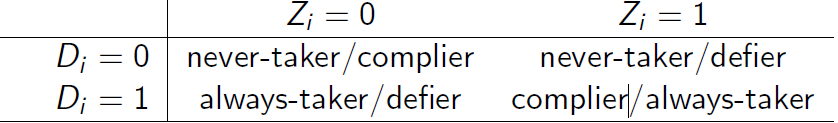

- If there were defiers, it would change our estimate of the effect of D
- We need to assume there aren’t any

## LATE for class

- Heterogeneous treatment effects changes our interpretation
- We no longer estimate an ATE, or even a TOT
- Now we estimate a LATE
  - Local Average Treatment Effect
- LATE is the effect of the treatment on those whose treatment status is altered by the instrument

## Class Exercise

- Run ci_mixtape_iv.R from canvas
- Explain what the IV is
- What is the finding using OLS?
- Using IV?
- Check the first stage for power

## Popular IV Designs

- There are many IV designs that have been used repeatedly
- We will go through 3 of them
  - Lotteries
  - Judge fixed effects
  - Bartik (shift-share) instruments

## Lotteries

- There are often policy ‘treatments’ that many people want
- When $Supply < Demand$, spots can be allocated via lotteries
  - Can compare those who signed up and lost with those who won
- Examples
  - Medicaid experiment (Oregon)
  - School choice lotteries
  - Recent trend - using effectiveness of IVF as a ‘lottery’

## Effect of Health Insurance

- The effect of insurance on health outcomes is not immediately obvious
- Insurance could lead to overutilization
- Also potential for a **Peltzman Effect**
- In the US, who has insurance is far from random

## Enter the Oregon Medicaid Experiment

- In the early 2000s, Oregon expanded Medicaid
- Anyone 19-64 under the FPL was eligible to apply
- Widely advertised and easy to sign up
- 85k people applied
- Oregon chose 30k via lottery
- of them, 10k enrolled

## Several influential papers written on oregon experiment

- Finkelstein et al (2012)
  - $\uparrow$ utilization
  - $\downarrow$ out of pocket expenses
  - $\uparrow$ self-reported physical and mental health
  - No effect on mortality
- Baicker et al (2012)
  - $\uparrow$ diagnosis of diabetes and med use
  - $\downarrow$ probability of depression diagnosis
  - $\uparrow$ preventive services
  - $\downarrow$ catastrophic medical expenses

## School choice lotteries

- Mixed results on student achievement
- Cullen et al (2006) - winning lottery leads to
  - $\downarrow$ disciplinary events
  - $\downarrow$ arrests
- Bibler and Billings (2020) - Losing a school choice lottery leads to residential sorting
- Bibler et al (2023) - SCL increases arrests for students left behind

## IVF as a lottery

- Understanding the effect of children on labor market outcomes is famously difficult
- Need a setting where people are similar on observables, but some are randomly allocated children
- IVF provides this
- Odds of conceiving are about 40% for 35 years olds, with odds decreasing in age
- Strategy: compare IVF successes and failures
  - Deals with most of the endogeneity

## Lundborg et al (2017)

- Look at the effect of IVF on women’s careers
- When IVF is successful
  - $\downarrow$ hourly earnings
  - $\downarrow$ employment
  - Effects are long-lasting

## Judge Fixed Effects Design

- We like to think that judges are impartial and fair to all defendants
- Turns out there are lots of things that can influence judge decisions
  - Lunchtime (Danziger and Levav (2011))
  - College football (Mocan and Eren (2017))
- It also turns out that some judges are much harsher in general than others

## Say we want to know the effect incarceration

- Typically, you only go to prison for more serious crimes
- We would expect people sent to prison to have worse outcomes
- What if two people comitted the same crime, but one gets incarcerated just because they had a harsh judge?
- Turns out this happens **a lot**

## First used in Gaudet et al (1933)

- Analyzed 7,000 cases **randomly assigned** to 6 judges
- Some judges were almost twice as likely to incarcerate

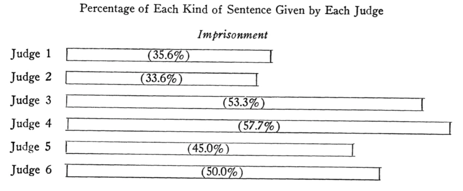

## Judge FE greatest hits

- Mueller-Smith (2015) - Incarceration leads to
  - $\uparrow$ recidivism
  - $\downarrow$ labor market outcomes
  - $\uparrow$ public assistance
- Arnold et al (2018) use judge FE’s to show that judges are racially biased against black defendants in bail decision
- Aizer and Doyle (2015) - being sent to foster care:
  - $\uparrow$ juvenile delinquency
  - $\uparrow$ teen pregnancy
  - $\downarrow$ adult employment

## Threats to identification

- What if a defendant/lawyer knows a judge is harsh
- If they can get reassigned, then we have a problem
- Need to know institutional details
- Still, original assignment could serve as IV

## Threats pt 2 - Monotonicity

- Monotonicity assumption requires judge harshness always work in the same direction
- If one judge is harsher, they need to be at least as harsh on all cases
- What if a judge is lenient, but kinda racist?
- What if a judge is only harsh on drug cases?
- These are problems, but are testable in the end.

## Bartik (shift-share) instruments

- Say we want to know the effect of employment growth on labor market outcomes
- OLS is likely hopelessly biased
- Bartik IVs typically rely on two facts:
  - Employment shocks typically hit different industries
  - Different regions have different industry composition
- Certain regions are then differentially impacted by national recessions
  - Example - Detroit in 2008-09

## Immigration version of Bartik

- To study the effect of immigration on local labor markets
- People obviously try to immigrate to places with strong economies
- There are often ‘push factors’ that cause immigrants to leave a certain area
- Immigrants typically move to areas where other people from their home country have already moved

## Immigration example

- Early 1900’s - many Norwegians came to the US to flee poverty and religious persecution
- Different parts of the US will have different ‘stocks’ of those types of immigrants
- Being in a county with a Norwegian population pre-1900 can then serve as an IV for receiving immigrants

## Bartik setup

- The typically Bartik instrument looks like:

$B_{l,t} = \sum_{k=1}^K Z_{l,k,t^0}*M_{k,t}$

- $Z_{l,k,t^0}$ is the initial ($t^0$) share
  - of county $l$
  - from country $k$ (Norway) to location $l$
- $M_{k,t}$ is the nationwide change in immigration
  - from country $k$ at time $t$ -$B_{l,t}$ can then measure the effect of immigration on…

## Class example - COVID recession shift-share

- Use county_ind_comp_2019 and covid_emp_industry
- Calculate the percentage of job loss in each industry using covid_emp_industry. Call this ind_loss
- Calculate the share of each county’s 2019 employment in each industry (ind_exposure)
- Merge the two based on naics code
- Create a county-level measure of exposure to the COVID recession by multiplying ind_loss and ind_exposure
- Create a county-level map of this measure for the whole US

## Tips

- Use group_by() and then sum() to get total employment in a county
- When you’ve got your measure, you only want one observation per county
  - Use group_by() then summarise()
- Also use filter(is.na(covid_exposure)==FALSE)

## Solution

```r
covid_emp_industry <- haven::read_dta("covid_emp_industry.dta") %>%
  mutate(ind_loss = (emp_2019-emp_2020)/emp_2019)

county_ind_comp_2019 <- haven::read_dta("county_ind_comp_2019.dta") %>%
  group_by(countyfips) %>%
  mutate(total_emp = sum(employment),
         ind_exposure = employment/total_emp,
         fips = countyfips)

covid_bartik <- merge(covid_emp_industry, county_ind_comp_2019) %>%
  mutate(covid_exposure = ind_loss * ind_exposure) %>%
  group_by(fips) %>%
  summarise(covid_exposure = sum(covid_exposure)) %>%
  filter(is.na(covid_exposure)==FALSE)
```

## Solution

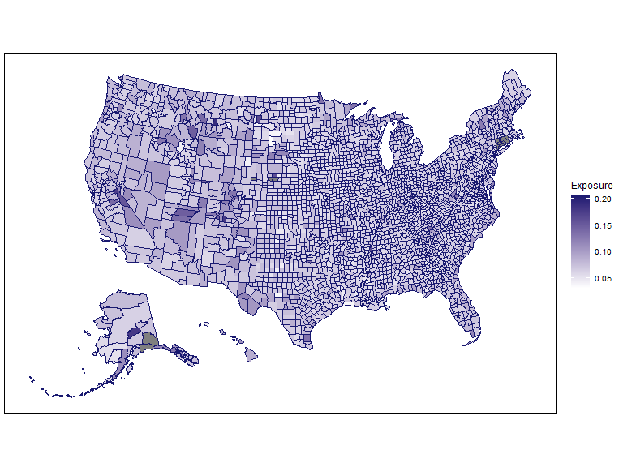

## That doesn’t look great. Let’s look at the density

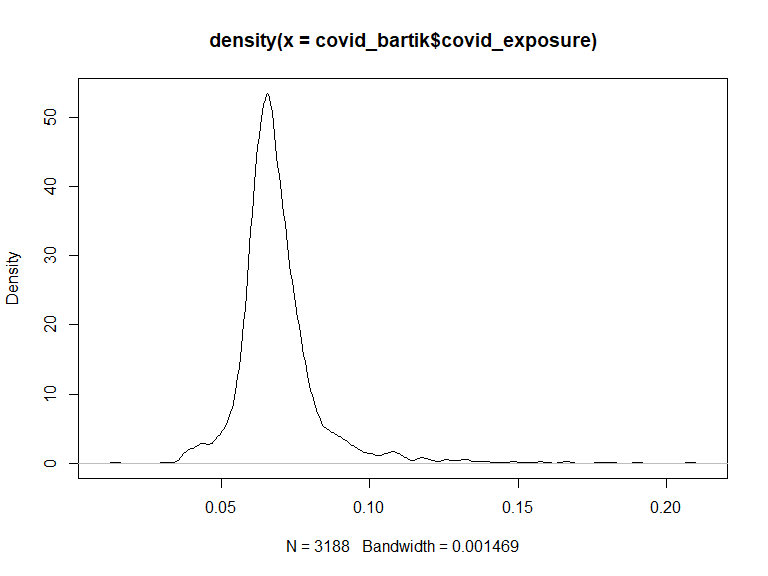

```r
plot(density(covid_bartik$covid_exposure))
```

```r
covid_bartik <- covid_bartik %>%
  mutate(exp_trunc = ifelse(covid_exposure>.1,.1,covid_exposure))
```

- Let’s truncate at .1

## Truncated version

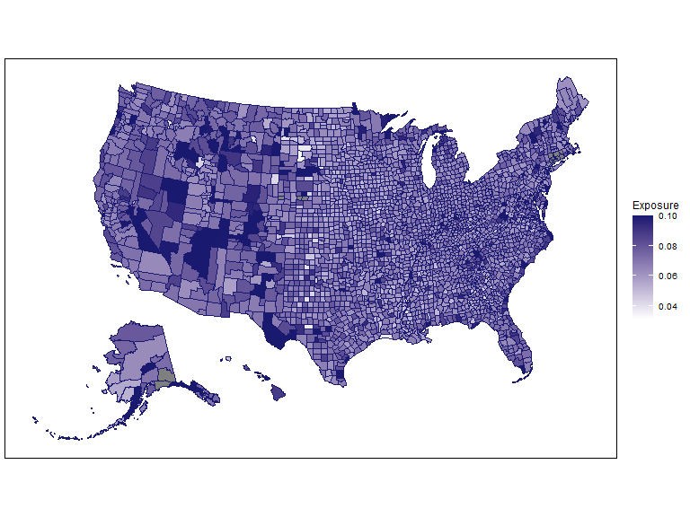